# A1

```r
b$out
```

```
##  [1] 74 68 74 64 68 64 68 68 74 68 64 74 72 68 74
```

```r
# On són localitzats aquest outliers.
which(df[5] < 75, arr.ind=TRUE)
```

```
##       row col
##  [1,]   4   1
##  [2,]   5   1
##  [3,]  16   1
##  [4,]  63   1
##  [5,]  78   1
##  [6,]  95   1
##  [7,] 127   1
##  [8,] 134   1
##  [9,] 140   1
## [10,] 155   1
## [11,] 194   1
## [12,] 210   1
## [13,] 240   1
## [14,] 248   1
## [15,] 286   1
```

```r
df[c(4,5,16,63,78,95,127,134,140,155,194,210,240,248,286),]
```

|  | HP | City | Day | BW | BPD | AD | Sex | Ge | Sm | Hora | Minut |
| --- | --- | --- | --- | --- | --- | --- | --- | --- | --- | --- | --- |
| 4 | H.Clínic | Barcelona | Dijous | 1300 | 74 | 71 | M | 33 | S | 18 | 38 |
| 5 | H.U.12 de octubre | Madrid | Dimecres | 1150 | 68 | 80 | F | 33 | S | 9 | 53 |
| 16 | H.Clínic | Barcelona | Dimecres | 1250 | 74 | 94 | F | 33 | S | 24 | 0 |
| 63 | H.U.de Bellvitge | Barcelona | Dijous | 1025 | 64 | 71 | M | 33 | S | 15 | 32 |
| 78 | H.U.12 de octubre | Madrid | Divendres | 1150 | 68 | 80 | F | 33 | S | 9 | 10 |
| 95 | H.M.I. Virgen de las Nieves | Granada | Dissabte | 1250 | 64 | 71 | F | 33 | S | 24 | 0 |
| 127 | H.U.de Bellvitge | Barcelona | Divendres | 1150 | 68 | 73 | F | 33 | S | 21 | 23 |
| 134 | H.U.Politècnic La Fe | Valencia | Dilluns | 1150 | 68 | 80 | M | 33 | S | 6 | 43 |
| 140 | H.U.Politècnic La Fe | Valencia | Dijous | 1250 | 74 | 94 | F | 33 | S | 13 | 32 |
| 155 | H.U.Vall d'Hebron | Barcelona | Dimarts | 1150 | 68 | 80 | M | 33 | S | 16 | 18 |

[output cut: 5 more lines]

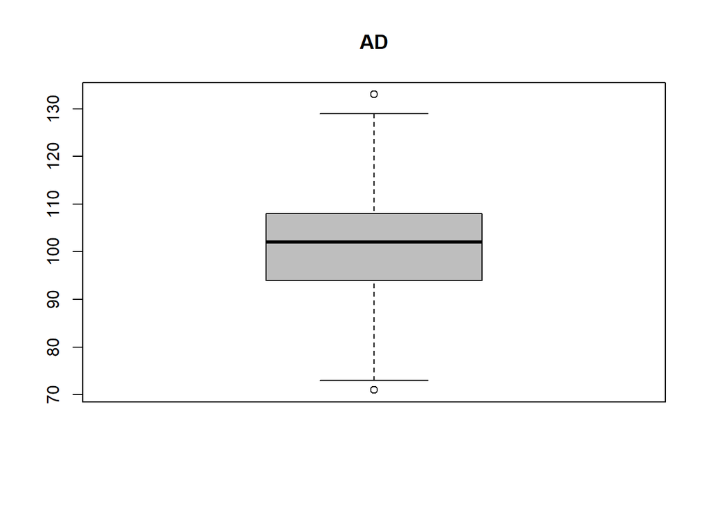

```r
# Igual que abans, no crec que sigui bona idea borrar aquest outliers perquè semblen dades autèntiques, hospitals diferents, dia i hores diferents. Hi ha una probabilitat de que el nadó segui físicament petit si es cumpleix que són 33 setmanes de gestiació i la mare és fumadora.



b <- boxplot(df[6],main="AD", col="gray")
```

```r
b$out
```

```
##  [1] 133  71 133  71  71 133 133  71 133  71
```

```r
which(df[6] < 75, arr.ind=TRUE)
```

```
##      row col
## [1,]   4   1
## [2,]  63   1
## [3,]  95   1
## [4,] 127   1
## [5,] 194   1
## [6,] 210   1
## [7,] 240   1
```

```r
which(df[6] > 130, arr.ind=TRUE)
```

```
##      row col
## [1,]   3   1
## [2,]  47   1
## [3,] 173   1
## [4,] 183   1
## [5,] 196   1
```

```r
df[c(4,63,95,194,210,240,3,47,173,183,196),]
```

|  | HP | City | Day | BW | BPD | AD | Sex | Ge | Sm | Hora | Minut |
| --- | --- | --- | --- | --- | --- | --- | --- | --- | --- | --- | --- |
| 4 | H.Clínic | Barcelona | Dijous | 1300 | 74 | 71 | M | 33 | S | 18 | 38 |
| 63 | H.U.de Bellvitge | Barcelona | Dijous | 1025 | 64 | 71 | M | 33 | S | 15 | 32 |
| 95 | H.M.I. Virgen de las Nieves | Granada | Dissabte | 1250 | 64 | 71 | F | 33 | S | 24 | 0 |
| 194 | H.Clínic | Barcelona | Divendres | 1250 | 64 | 71 | M | 33 | S | 12 | 40 |
| 210 | C.U.Navarra | Pamplona | Dissabte | 1300 | 74 | 71 | M | 33 | S | 7 | 6 |
| 240 | H.U.de Bellvitge | Barcelona | Dissabte | 1173 | 72 | 73 | F | 33 | S | 8 | 22 |
| 3 | H.U.de Bellvitge | Barcelona | Dimarts | 4200 | 97 | 133 | F | 43 | N | 24 | 0 |
| 47 | H.U.Quirón Dexeus | Barcelona | Dissabte | 4200 | 97 | 133 | F | 43 | N | 14 | 16 |
| 173 | H.U.Vall d'Hebron | Barcelona | Dijous | 4200 | 97 | 133 | M | 43 | N | 7 | 19 |
| 183 | H.U.12 de octubre | Madrid | Dimecres | 4200 | 95 | 133 | F | 43 | N | 9 | 32 |

[output cut: 1 more lines]

```r
# Per la mateixa raó que abans no puc esborrar aquestes dades perquè són uns pocs nadons que pesen poc i s'han gestat poques setmanes i la mare és fumadora. O bé són nados que pesen molt, gestats moltes setmanes i de mares sanes. Tot i ser valors "extrems" són valors correctes.
```

## 6 Taula resum de les variables qualitatives

Realitzar un resum descriptiu dels valors de les variables qualitatives.

```r
summary(df[1], maxsum = 20)
```

```
##                            HP
##  C.U.Navarra                :27
##  H.Clínic                   :25
##  H.G.U.Gregorio Marañón     :27
##  H.M.I. Virgen de las Nieves:30
##  H.U.12 de octubre          :26
##  H.U.de Bellvitge           :40
##  H.U.La Paz                 :18
##  H.U.Politècnic La Fe       :31
##  H.U.Quirón Dexeus          :36
##  H.U.Vall d'Hebron          :26
##  H.U.Virgen del Rocío       :14
```

```r
# Es mostra els diferents hospitals d'on s'han agafat les dades.

summary(df[2], maxsum = 20)
```

```
##      City
##  Length:300
##  Class :character
##  Mode  :character
```

```r
# Les diferentes ciutats espanyoles on són situats físicament els hospitals anteriors.

summary(df[3], maxsum = 20)
```

```
##      Day
##  Length:300
##  Class :character
##  Mode  :character
```

```r
# El dia de la setmana en que va nàixer el nado.

summary(df[7], maxsum = 20)
```

```
##      Sex
##  Length:300
##  Class :character
##  Mode  :character
```

```r
# Diferenciar si el nadó és mascle o femella.

summary(df[9], maxsum = 20)
```

```
##  Sm
##  N:238
##  S: 62
```

```r
# Separació entre si la mare del nadó, és o no és fumadora.
```

## 7 Taula resum de les variables quantitatives

Realitzar una taula de la tendència central i dispersió de les variables quantitatives. Feu servir mesures robustes i no robustes.

```r
# Per mostrar visualment la tendencia central, trobo que el gràfic on és podrà apreciar millor és un boxplot.

# Pes
summary(df$BW)
```

```
##    Min. 1st Qu.  Median    Mean 3rd Qu.    Max.
##    1025    2181    2680    2662    3100    4850
```

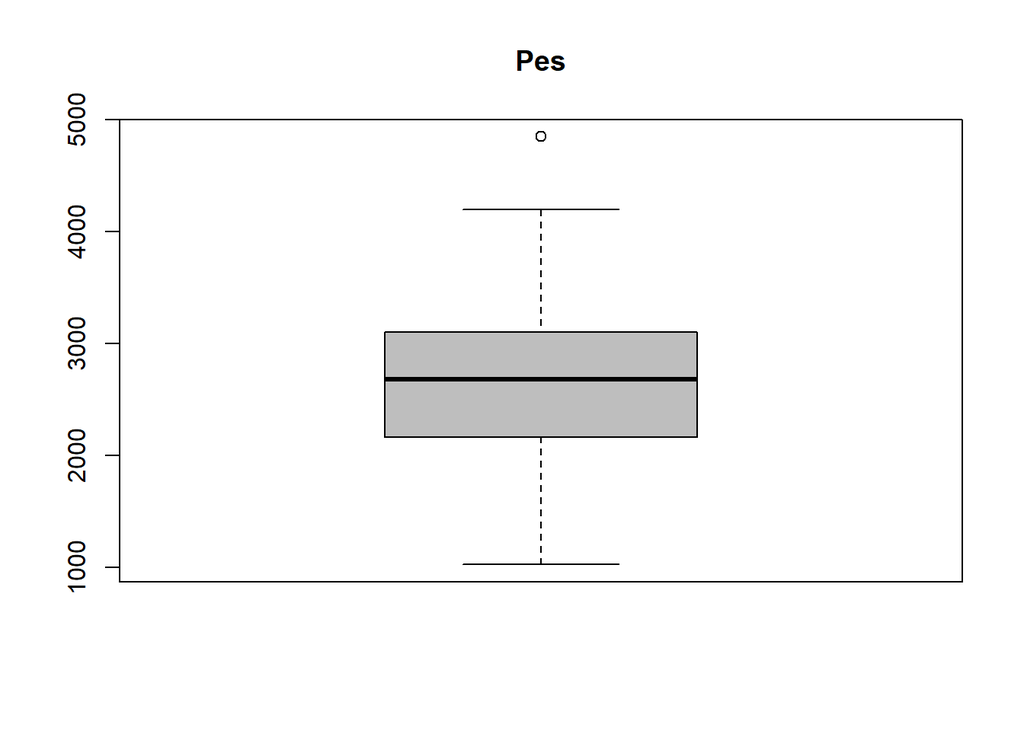

```r
b <- boxplot(df[4],main="Pes", col="gray")
```

```r
# Diàmetre biparietal
summary(df$BPD)
```

```
##    Min. 1st Qu.  Median    Mean 3rd Qu.    Max.
##   64.00   87.00   91.00   88.98   93.00  100.00
```

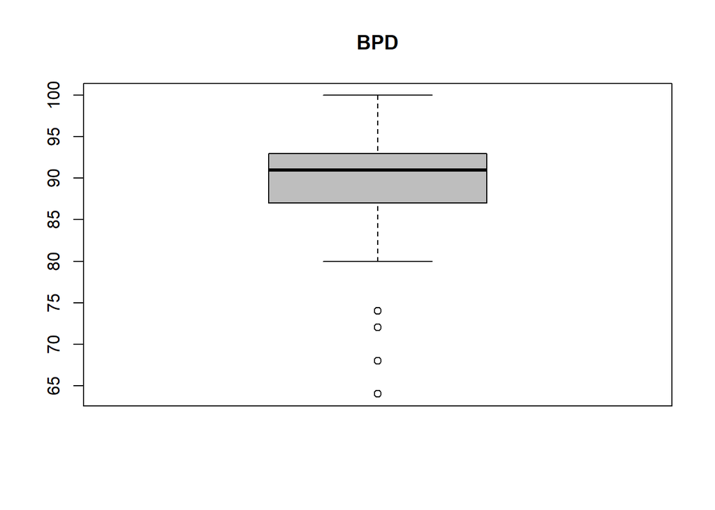

```r
b <- boxplot(df[5],main="BPD", col="gray")
```

```r
# Diàmetre abdominal
summary(df$AD)
```

```
##    Min. 1st Qu.  Median    Mean 3rd Qu.    Max.
##    71.0    94.0   102.0   100.9   108.0   133.0
```

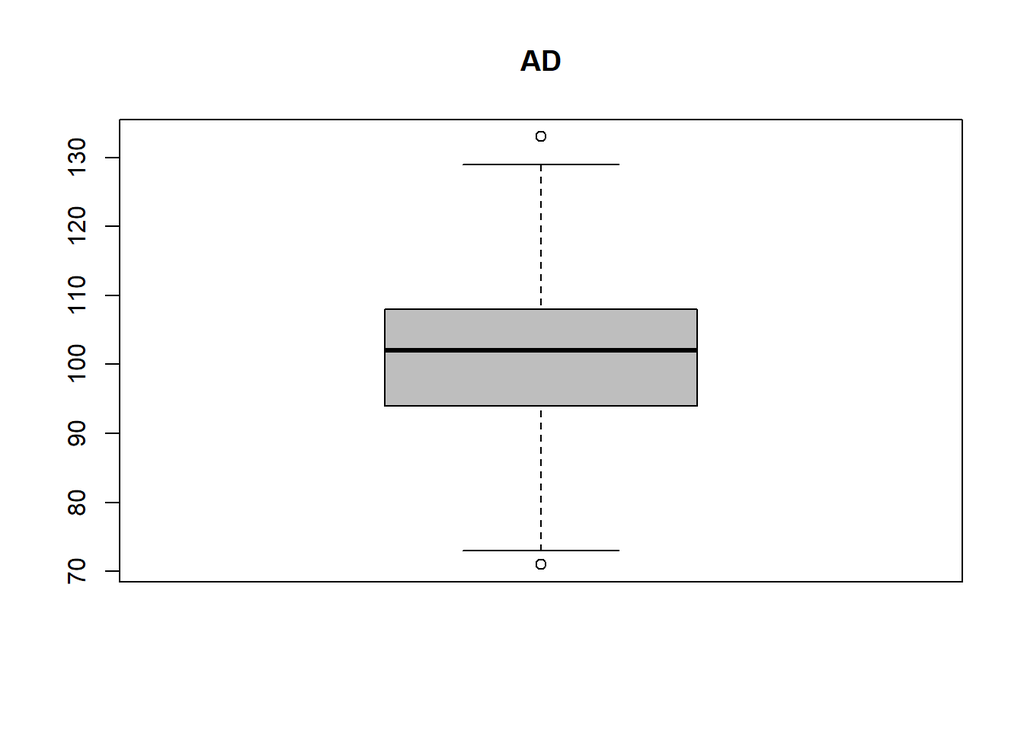

```r
b <- boxplot(df[6],main="AD", col="gray")
```

```r
# Setmanes de gestació
summary(df$Ge)
```

```
##    Min. 1st Qu.  Median    Mean 3rd Qu.    Max.
##   33.00   33.00   36.00   36.24   38.00   43.00
```

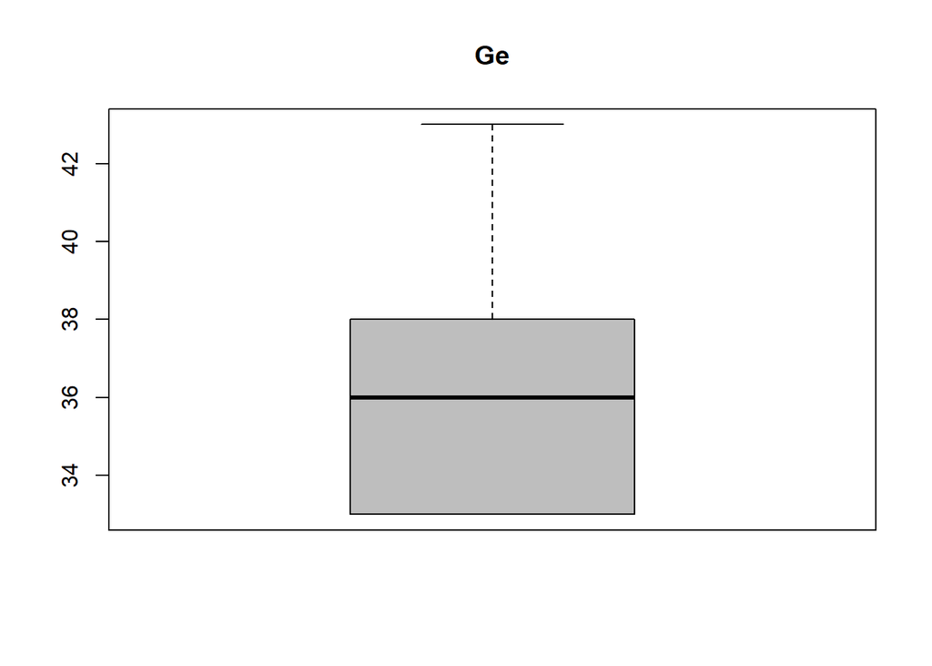

```r
b <- boxplot(df[8],main="Ge", col="gray")
```

## 8 Crear el fitxer net

Graveu les dades preprocessades en un fitxer anomenat “BWprocessed.csv”.

```r
write.csv(df, "C:\\Users\\garridom\\Documents\\UOC\\Estadistica\\A1\\BWprocessed.csv", row.names = FALSE)
```

## 9 Documentació

Documentar de forma resumida els canvis introduïts en el fitxer durant el preprocés d’ell mateix. Cal mostrar-se en forma de taula, indicant el tipus de preprocés aplicat en cada cas. Cal explicar el detall del preprocés aplicat. Per exemple, no és suficient dir “s’ha normalitzat la variable BW”. En tot cas, s’hauria d’indicar si s’ha reemplaçat la coma pel punt decimal, o si s’han arrodonit decimals, etcètera. Heu de ser específics, ja que l’informe ha de ser útil com a documentació dels canvis realitzats.

```r
library(knitr)
library(kableExtra)
df <- data.frame(Cat = c("Hospital", "Ciutat", "Dia de la setmana", "Sexe", "Mare fumadora", "Pes", "Diàmetre parietal", "Diàmetre abdominal", "Setmanes de gestació", "Temps"),Sad = linebreak(c("Veure que els hospitals concorden amb al ciutat on són", "Majúscules", "Pasar de variable numèrica, a String (factor)", "Reconvertir errates a l'introducció de les dades", "Cap", "Canvi de tipus de dades, canvi de mesura, suprimir o normalitzar caràcters rebundants", "Suprimir caracters rebundants", "Suprimir caràcters rebundants", "Arrodoniment", "Conversió i separació en dos columnes")),  Happy = linebreak(c("Escriure la ciutat corresponent de l'hospital on es troba físicament", "En algún cas, la ciutat de Sevilla i Valencia, els hi faltava la primera lletra en majúscula", "Fer set simples modificacions, si és 1, Dilluns, si és 7 Diumenge...", "Les dades han de ser M o F, trobar les altres formes que s'han introduït el sexe, tal com fem, nen. ", "Totes les dades eren correctes", "Treure caràcters (lletres), pasar les dades a numèriques, vigilar si són comes o punts, multiplicar per 1000 en el cas que siguin quilos", "Treure els caràcters d'unitat de mesura", "Treure els caràcters d'unitat de mesura", "Arrodonir al enter més pròxim","Primerament he substituit les comes per punts, l'he pasat de variable factor a variable numèrica. He convertit els minuts en format HH:MM. He eliminat la columa de temps i he creat dos de noves, una per la hora, l'altre pels minuts.")))

kable(df, col.names = c("", "Tipus de preprocés", "Descripció"), escape = F, caption = "Documentació") %>%
kable_styling(latex_options = "hold_position")
```

Documentació

[output not shown]